# Importing data from multiple files simultaneously in R

Gonzalo Garcia-Castro

2020-07-20

## Why this post

Below I provide several options for importing data from the different files, using base R and tidyverse, among other tools. I will compare how long it takes to import and merge data using each method under different circumstances. You can find the whole code here in case you want to take a look, reproduce it or play with it[^1].

## How can I import large files and merge them?

So we have some files in a folder. All files have the same number of columns, the same column names, and are in the same format. I assume that data are tabular (i.e., in the shape of a rectangle defined by rows and columns). I also assume that data are stored as Comma-Separated Values (.csv) or Tab-separated Text (.txt or .tsv), as these formats are the most reproducible.

We to import all files and bind their rows together to form a unique long data frame. There are multiple combinations of functions we can use. Each function comes with a different package and does the job in different ways. Next, I will show some suggestions, but first let’s create some data. We are creating 50 datasets with 10 columns and 10,000 rows in .txt format. The variables included are numeric and made of 0s and 1s. There is also a column that identifies the data set. These files are created in a temporary directory using the `temp.dir` function for reproducibility. After closing you R session, this directory and all of its contents will disappear.

```r
n <- 50 # number of files/participants
n_obs <- 10000 # number of rows/observations in each file
filenames <- sprintf("dataset%03d", 1:n) # file names
files <- lapply(
  as.list(filenames),
  function(x) {
    data.frame(dataset = x, replicate(10, sample(0:1, n_obs, rep = TRUE))) # create data sets
  }
)
# export data sets as files
dat <- mapply(
  function(x, y){
    write.table(x, paste0(tempdir(), .Platform$file.sep, y,  ".txt"), sep = "\t", dec = ".", row.names = FALSE)
  },
  files, filenames
)
```

### Base R: for loops

*for loops* are one of the fundamental skills in many programming languages. The idea behind *for loops* is quite intuitive: take a vector or list of length *n*, and apply a series of functions to each element in order. First, to element 1 and then to element 2, and so on, until we get to element *n*. Then, the loop ends. We will first make a vector with the paths of our files, and then apply the `read.delim` function to each element of the vector (i.e., to each path). Every time we import a file, we store the resulting data frame as an element of a list. After the loop finishes, we merge the rows of all element of the list using a combination of the functions `do.call` and `rbind`.

```r
n <- 20 # number of files
filepaths <- list.files(tempdir(), full.names = TRUE, pattern = ".txt") # list files in folder
dat <- list() # pre-allocate the list of files
for (i in 1:length(filepaths)){
  dat[[i]] <- read.delim(filepaths[i])
}
dat <- do.call(rbind, dat) #  bind data frames together
```

### Base R: `lapply`

We will use the functions `read.delim` and `read.csv` in combination with the function `lapply`. The former are well known. The later is part of a family of functions (together with `sapply`, `mapply`, and some others I can’t remember) that take two arguments: a list and a function, which will be applied over each element of the list in parallel (i.e., in a vectorised way).

```r
filepaths <- list.files(tempdir(), full.names = TRUE, pattern = ".txt")
dat <- lapply(filepaths, read.delim)
dat <- do.call(rbind, dat)
```

### tidyverse

The tidyverse is a family of packages that suggests a workflow when working in R. The use of pipes (`%>%`) is one of its signature moves, which allow you to chain several operations applied on the same object within the same block of code. In contrast, base R makes you choose between applying several functions to the same object in different blocks of code, or applying those functions in a nested way, so that the first functions you read are those applied the last to your object (e.g., `do.call(rbind, as.list(data.frame(x = "this is annoying", y = 1:100)))`). We will use a combination of the `dplyr` and `purrr` packages to import the files listed in a vector, using `read.delim` and `bind_rows`.

```r
library(dplyr)
```

```r
library(purrr)

filepaths <- list.files(tempdir(), full.names = TRUE, pattern = ".txt")
dat <- map(filepaths, read.delim) %>%
  bind_rows()
```

### `data.table`

The function `rbindlist` function from the package `data.table` also allows to merge the datasets contained in a list. In combination with `fread` (from the same package), it can be very fast.

```r
library(dplyr)
library(data.table)

filepaths <- list.files(tempdir(), full.names = TRUE, pattern = ".txt")
dat <- map(filepaths, fread) %>%
  rbindlist()
```

## What method is the fastest?

I will compare how long each combination of importing, vectorising, and merging functions needs to import 50 data sets with 10 columns and 10,000 rows each. Additionally, I will compare the performance of each method when working with CSV (.csv) and TSV (.txt) files. For each method, I will repeat the process 100 times, measuring how long it takes from the moment we list the extant files in the folder to the moment we finish merging the data sets. Here are the results:

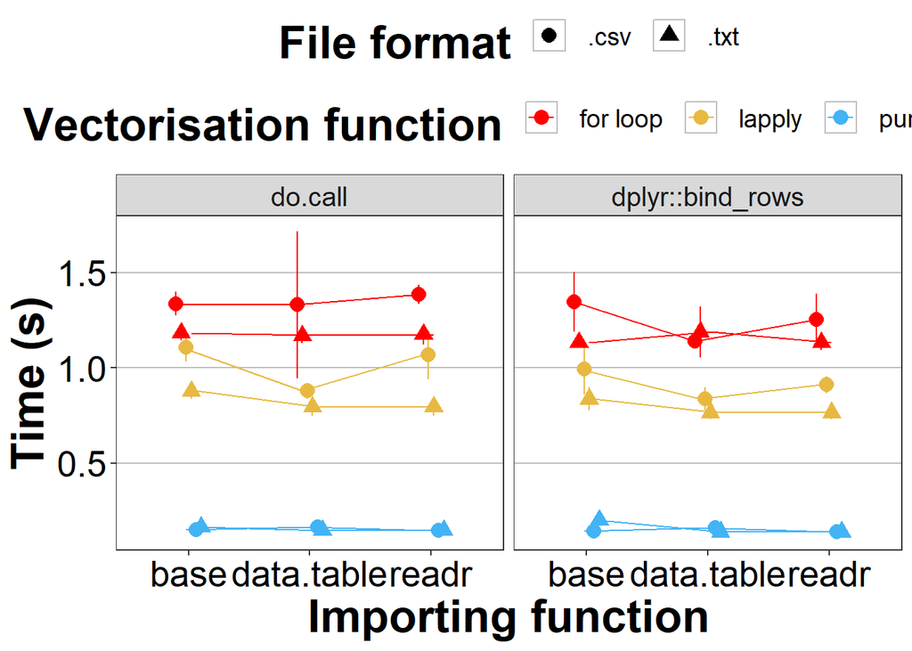

Mean time (and standard deviation) for each combination of methods and file formats across 100 replications

For more detail:

Time taken to import and merge

50 datasets with 10 columns and 10,000 rows each

|  | package | **for loop** *M* | **for loop** *SD* | **lapply** *M* | **lapply** *SD* | **purrr::map** *M* | **purrr::map** *SD* |
| --- | --- | --- | --- | --- | --- | --- | --- |
| do.call - .csv |  |  |  |  |  |  |  |
|  | base | 1.34 | 0.06 | 1.11 | 0.07 | 0.15 | 0.03 |
|  | data.table | 1.33 | 0.39 | 0.88 | 0.04 | 0.17 | 0.02 |
|  | readr | 1.38 | 0.05 | 1.07 | 0.13 | 0.15 | 0.02 |
| dplyr::bind_rows - .csv |  |  |  |  |  |  |  |
|  | base | 1.35 | 0.16 | 0.99 | 0.14 | 0.15 | 0.01 |
|  | data.table | 1.14 | 0.04 | 0.84 | 0.06 | 0.16 | 0.01 |
|  | readr | 1.25 | 0.14 | 0.91 | 0.04 | 0.14 | 0.00 |
| do.call - .txt |  |  |  |  |  |  |  |
|  | base | 1.18 | 0.04 | 0.88 | 0.04 | 0.17 | 0.02 |
|  | data.table | 1.17 | 0.04 | 0.80 | 0.05 | 0.15 | 0.02 |
|  | readr | 1.18 | 0.05 | 0.80 | 0.05 | 0.15 | 0.02 |
| dplyr::bind_rows - .txt |  |  |  |  |  |  |  |
|  | base | 1.13 | 0.03 | 0.84 | 0.06 | 0.20 | 0.02 |
|  | data.table | 1.19 | 0.13 | 0.77 | 0.03 | 0.14 | 0.01 |
|  | readr | 1.13 | 0.04 | 0.77 | 0.03 | 0.14 | 0.01 |
| Mean | — | 1.23 | 0.10 | 0.89 | 0.06 | 0.15 | 0.02 |

## Conclusion

Under the scenario under which I have simulated the data, it seems that using `purrr::map` in combination with `do.call` or `dplyr::bind_rows` to merge data sets is the most efficient method in terms of time. When using said combination, it doesn’t matter what function we use to import files, but `data.table::fread` seems like the best choice, as it is also the most flexible (take a look at the [documentation](https://github.com/Rdatatable/data.table) of `data.table` to see all the features it offers).

If I have time, I may add another two dimensions: number of rows in the files and number of files, although I dare say similar results are to be expected. If anything, I would say that differences may become greater as file size and number of files increase. Also, it would be interesting to test if pre-allocating the elements of the vector in the for loop speeds up the process (see here what I mean). We shall see.

Hope this was useful, if not interesting!

## Code

[^1]: Ironically, this code is super inefficient and messy. It takes ages to run, and has been written by copy-pasting multiple times. I didn’t feel like doing anything more elegant. Also, I don’t know how. Help yourself.